# suppl_info_beckers_etal_2016_jneurobiorev_revision2

This jupyter notebook contains the supplementary information of the paper:

Beckers, G.J.L., Berwick B.C., Okanoya, K. and Bolhuis, J.J. (2016) What do animals learn in artificial grammar studies? Neuroscience & Biobehavioral Reviews [http://dx.doi.org/10.1016/j.neubiorev.2016.12.021]

To run it, install the Python package *aglcheck* [https://github.com/gjlbeckers-uu/aglcheck]

Revision 1:

20170131: corrected color bar label "milliseconds" to "seconds" in Figure S3  
20170131: fixed an internal link

Revision 2:

20170913: made notebook compatible with refactoring aglcheck, no changes in output

```python
from IPython.display import HTML
HTML('''<script>
code_show=true;
function code_toggle() {
 if (code_show){
 $('div.input').hide();
 } else {
 $('div.input').show();
 }
 code_show = !code_show
}
$( document ).ready(code_toggle);
</script>
The raw code for this IPython notebook is by default hidden for easier reading.
To toggle on/off the raw code, click <a href="javascript:code_toggle()">here</a>.''')
```

The raw code for this IPython notebook is by default hidden for easier reading. To toggle on/off the raw code, click here.

# Supplementary Information

## Contents

Supplementary Analysis 1 (based on stimuli from Saffran et al. 2008 and Wilson et al. 2015b)

- Table S1
- Table S2

Supplementary Analysis 2 (based on stimuli from Wilson et al. 2013)

- Table S3
- Figure S1

Supplementary Analysis 3 (based on stimuli from Wilson et al. 2015b)

- Table S4
- Figure S2

Supplementary Analysis 4 (based on stimuli from Wilson et al. 2015a)

- Table S5
- Figure S3

Supplementary Analysis 5 (based on stimuli from Chen and ten Cate 2015)

- Table S6
- Figure S5
- Table S7
- Figure S5
- Table S8
- Figure S6
- Table S9
- Figure S7

Supplementary Analysis 6 (based on stimuli from Wilson et al. 2013, 2015a, 2015b and Saffran et al. 2008)

- Figure S8
- Figure S9

Supplementary Analysis 7 (based on stimuli from Abe and Watanabe, 2011)

- Figure S10

Supplementary Analysis 8 (based on stimuli from Chen et al, 2015)

- Figure S11
- Figure S12

Supplementary Analysis 9 (based on stimuli from Chen and ten Cate, 2015, and Wilson et al. 2013, 2015a, 2015b)

- Figure S13

```python
from __future__ import print_function
import numpy as np
%matplotlib inline
import matplotlib.pyplot as plt
from IPython.core.display import HTML
from aglcheck import get_examplestringdata
from aglcheck.stringsetcomparison import longestsharedsubstringlength, longestsharedsubstringduration, \
    commonstartlength, commonstartduration, crosscorrelationmax, samestart, issubstring
from aglcheck.plotting import plot_comparison
from aglcheck.htmltables import issubstringtable, longestsharedsubstringstable
```

## Supplementary Analysis 1

The string sets originate from Experiment 3 in: Saffran J, Hauser M, Seibel R, Kapfhamer J, Tsao F, Cushman F (2008) Grammatical pattern learning by human infants and cotton-top tamarin monkeys. Cognition 107:479–500. [link](http://www.sciencedirect.com/science/article/pii/S0010027707002697)

In Experiment 3 of this paper, cotton-top tamarins are familiarized with two languages, a P-language, which contains predictive dependencies, and a NP-language, which does not contain such predictive dependencies. Tamarins were tested with grammatical and ungrammatical test strings one day after familiarization with either a P-language or a NP-language. Grammatical test strings conform to the grammar of both languages and ungrammatical test strings violate the grammar of both languages. The idea behind this experiment is to test if the P-language, is more easily learned by the tamarins. If so, tamarins should distinguish between the grammatical and ungrammatical strings better after they have been familiarized with the P-language.

In this particular experiment (but not in all other ones reported in the same paper), the tokens from which the strings constructed are particular sounds, not sound classes. The sounds are the speech syllables "biff", "cav", "dupp", "klor", and "jux" (see their Table 1 [link](http://www.sciencedirect.com/science/article/pii/S0010027707002697#tbl1)), here denoted as {b,c,d,k,j}.

The results show that: "In the P-Language condition, tamarins responded significantly more to the ungrammatical items than the grammatical items [Wilcoxon, z = 3.19, p = .001]. In contrast, they showed no statistically significant pattern of response to the NP language [Wilcoxon, z = 0.4, p = .69]. An ANOVA examining the interaction between items (grammatical and ungrammatical) and conditions (P-language and NP language) was significant [F(1, 33) = 4.56, p < .05]."

The authors conclude (p. 491) that this suggests "that tamarins are able to detect regularities in a simple grammar, written over individual word tokens, when predictive dependencies are present."

However, there is a bias in how often test strings are fully contained within familiarization strings (Table S1): ungrammatical test strings never fully occur in any familiarization string, but the grammatical test strings do, and not in a balanced way. In half the of grammatical test strings (GTS_1 and GTS_3) this occurs three times as often in P-language strings than in NP-language strings. Thus, before they are tested the tamarins have been familiarized more extensively with complete grammatical test string sounds from the P-language than with complete grammatical test string sounds from the NP-language. This bias does not exist in the ungrammatical test strings (UTS), which are never fully present in either language. This provides a non-grammatical explanation for the results.

## Table S1

**Test strings that are *fully* contained within familiarization strings in Experiment 3 of Saffran et al. (2008)**. Matches are indicated in orange. The strings (from their Table 2 [link](http://www.sciencedirect.com/science/article/pii/S0010027707002697#tbl2)) are here labeled as follows:

Familiarization strings (rows):

- PLS: P-language familiarization strings
- NPLS: NP-language familiarization strings

Test strings (columns):

- GTS: grammatical test strings
- UTS: ungrammatical test strings

```python
stringdata = get_examplestringdata('saffranetal_cog_2008')
#print(stringdata.comparisons['full'][0].values())
#stringdata.print_strings()
cm = issubstringtable(stringdata, comparison=('Test','Fam'), title='')
HTML(cm)
```

|  | GTS_1 bcd | GTS_2 bkcjd | GTS_3 bkcd | GTS_4 bcjd | UTS_1 bckd | UTS_2 bjcd | UTS_3 bkd | UTS_4 bcjkd |
| --- | --- | --- | --- | --- | --- | --- | --- | --- |
| PLS_1 bcd | bcd bcd |  |  |  |  |  |  |  |
| PLS_2 bcjd |  |  |  | bcjd bcjd |  |  |  |  |
| PLS_3 bkcjd |  | bkcjd bkcjd |  |  |  |  |  |  |
| PLS_4 bkcd |  |  | bkcd bkcd |  |  |  |  |  |
| PLS_5 bcdcj | bcdcj bcd |  |  |  |  |  |  |  |
| PLS_6 bkcdcj |  |  | bkcdcj bkcd |  |  |  |  |  |
| PLS_7 bcdc | bcdc bcd |  |  |  |  |  |  |  |
| PLS_8 bkcdc |  |  | bkcdc bkcd |  |  |  |  |  |
| NPLS_1 bcd | bcd bcd |  |  |  |  |  |  |  |
| NPLS_2 bcjd |  |  |  | bcjd bcjd |  |  |  |  |
| NPLS_3 bkcjd |  | bkcjd bkcjd |  |  |  |  |  |  |
| NPLS_4 bkcd |  |  | bkcd bkcd |  |  |  |  |  |
| NPLS_5 kcjd |  |  |  |  |  |  |  |  |
| NPLS_6 bkjd |  |  |  |  |  |  |  |  |
| NPLS_7 kcd |  |  |  |  |  |  |  |  |
| NPLS_8 bjd |  |  |  |  |  |  |  |  |

Another study where a bias in this type of similarity is present is: Wilson B, Smith K, Petkov CI (2015) Mixed-complexity artificial grammar learning in humans and macaque monkeys: evaluating learning strategies. Eur J Neurosci 41:568–578. [link](http://onlinelibrary.wiley.com/doi/10.1111/ejn.12834/full). We discuss this study in more detail in Supplementary Analysis 3, and will here only show the matching strings in Table S2.

## Table S2

**Test strings that are *fully* contained within exposure strings in Wilson et al. (2015b)**. Matches are indicated in orange. The strings are from their Figure 1 [link](http://onlinelibrary.wiley.com/doi/10.1111/ejn.12834/full#ejn12834-fig-0001).

The string labeling below is ours:

Exposure (i.e. familiarization) strings (rows):

- E1 - E8

Test strings (columns):

- T01 - T04 are grammar conforming test strings
- T05 - T12 are grammar violating test strings, to differing extents

```python
stringdata = get_examplestringdata('wilsonetal_ejn_2015')
HTML(issubstringtable(stringdata, comparison=('Test', 'Exposure'), title=''))
```

|  | T01 acfcg | T02 adcfc | T03 acgfc | T04 adcgf | T05 adcfg | T06 adfcg | T07 adgcf | T08 adgfc | T09 agcfc | T10 agfgc | T11 agdcf | T12 agfdc |
| --- | --- | --- | --- | --- | --- | --- | --- | --- | --- | --- | --- | --- |
| E1 acf |  |  |  |  |  |  |  |  |  |  |  |  |
| E2 acfcg | acfcg acfcg |  |  |  |  |  |  |  |  |  |  |  |
| E3 acgf |  |  |  |  |  |  |  |  |  |  |  |  |
| E4 acgfcg |  |  | acgfcg acgfc |  |  |  |  |  |  |  |  |  |
| E5 adcf |  |  |  |  |  |  |  |  |  |  |  |  |
| E6 adcfc |  | adcfc adcfc |  |  |  |  |  |  |  |  |  |  |
| E7 adcfcg |  | adcfcg adcfc |  |  |  |  |  |  |  |  |  |  |
| E8 adcgfcg |  |  |  | adcgfcg adcgf |  |  |  |  |  |  |  |  |

Up to Supplementary Info Contents

## Supplementary Analysis 2

The string sets originate from: Wilson B, Slater H, Kikuchi Y, Milne AE, Marslen-Wilson WD, Smith K, Petkov CI (2013) Auditory Artificial Grammar Learning in Macaque and Marmoset Monkeys. J Neurosci 33:18825–18835. [link](http://www.jneurosci.org/content/33/48/18825.full)

In this paper, the authors first habituated macaque and marmoset monkeys to strings conforming to grammatical rules, and then presented them with test strings that are either consistent with these rules or that contain illegal violations. The goal is to test if monkeys can learn aspects of the artificial grammar. The macaques did differentiate between grammatical and ungrammatical test string in a way that the authors interpret as "... evidence for a previously unknown level of AGL complexity in Old World monkeys that seems less evident in New World monkeys ...".

The elements that were used to build the strings ({a,c,d,g,f}) stand for short nonsense words (a: "klor", c: "biff", d: "jux", f: "cav", g: "dupp").

The main figure of the results on which their conclusion is based, their Figure 2, is openly accessible: [link](http://www.jneurosci.org/content/33/48/18825/F2.expansion.html).

The analysis here (Table S3 and Figure S1) shows that grammar consistent test strings (Fam and Novel) share longer substrings with the habituation strings than grammar violating test strings do, which provides a non-grammatical explanation for the results.

The strings (from their Figure 1 [link](http://www.jneurosci.org/content/33/48/18825/F1.expansion.html)) are here labeled as follows:

Habituation strings (rows):

- Hab

Test strings (columns):

- Fam: familiar test strings' (i.e. identical to Hab strings)
- Novel: grammar consistent test strings
- Viol_bA: grammar violating test strings that begin with an _a_
- Viol_nbA: grammar violating test strings that do not begin with an _a_

## Table S3

**Longest substrings that are shared between habituation and test strings in Wilson et al. 2013**. A quantification of substring lengths, and corresponding durations, is shown in Figure S1 below.

```python
stringdata = get_examplestringdata('wilsonetal_jneurosci_2013')
HTML(longestsharedsubstringstable(stringdata, comparison=('Test','Hab'), minlen=2, title=''))
```

|  | Fam_1 acgfc | Fam_2 adcfcg | Novel_1 acfcg | Novel_2 adcgfc | Viol_bA_1 afgcd | Viol_bA_2 afcdgc | Viol_nbA_1 fadgc | Viol_nbA_2 dcafgc |
| --- | --- | --- | --- | --- | --- | --- | --- | --- |
| Hab_1 acf | acf acgfc | acf adcfcg | acf acfcg |  |  |  |  |  |
| Hab_2 acfc | acfc acgfc acfc acgfc | acfc adcfcg | acfc acfcg | acfc adcgfc |  | acfc afcdgc |  |  |
| Hab_3 acgf | acgf acgfc | acgf adcfcg | acgf acfcg acgf acfcg | acgf adcgfc |  |  |  |  |
| Hab_4 acgfc | acgfc acgfc | acgfc adcfcg acgfc adcfcg | acgfc acfcg acgfc acfcg acgfc acfcg | acgfc adcgfc |  | acgfc afcdgc |  |  |
| Hab_5 acgfcg | acgfcg acgfc | acgfcg adcfcg | acgfcg acfcg | acgfcg adcgfc |  | acgfcg afcdgc |  |  |
| Hab_6 adcf |  | adcf adcfcg | adcf acfcg | adcf adcgfc |  |  | adcf fadgc | adcf dcafgc |
| Hab_7 adcfc | adcfc acgfc | adcfc adcfcg | adcfc acfcg | adcfc adcgfc |  | adcfc afcdgc | adcfc fadgc | adcfc dcafgc |
| Hab_8 adcfcg | adcfcg acgfc adcfcg acgfc | adcfcg adcfcg | adcfcg acfcg | adcfcg adcgfc |  | adcfcg afcdgc | adcfcg fadgc | adcfcg dcafgc |
| Hab_9 adcgf | adcgf acgfc | adcgf adcfcg | adcgf acfcg | adcgf adcgfc |  |  | adcgf fadgc | adcgf dcafgc |

## Figure S1

**Image plots showing (A) the number of tokens and (B) corresponding duration of the longest substrings shared between habituation and test strings in Wilson et al. 2013**. Grammar consistent strings (Fam and Novel) have longer shared substrings with habituation strings than grammar violation strings (Viol_bA and Viol_nbA) do.

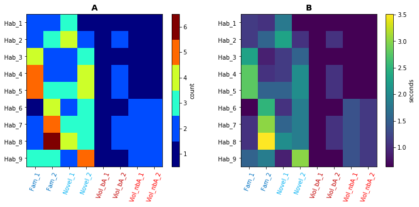

```python
plt.figure(figsize=(12,4.8))
stringdata = get_examplestringdata('wilsonetal_jneurosci_2013')
plt.subplot(1,2,1)
m = longestsharedsubstringlength(stringdata, comparison=('Test','Hab'))
plot_comparison(m, title='A', colorbarshrink=1, colorbarlabel='count')
ax = plt.gca()
t = ax.set_title('A', fontdict={'fontweight': 'bold', 'fontsize': 14})
plt.subplot(1,2,2)
m = longestsharedsubstringduration(stringdata, comparison=('Test','Hab'))
plot_comparison(m, title='B', colorbarshrink=1, colorbarlabel='seconds')
ax = plt.gca()
t = ax.set_title('B', fontdict={'fontweight': 'bold', 'fontsize': 14})
```

Up to Supplementary Info Contents

## Supplementary Analysis 3

The string sets originate from: Wilson B, Smith K, Petkov CI (2015) Mixed-complexity artificial grammar learning in humans and macaque monkeys: evaluating learning strategies. Eur J Neurosci 41:568–578. [link](http://onlinelibrary.wiley.com/doi/10.1111/ejn.12834/full)

In this paper, the authors state in the abstract: "Here, we tested humans and Rhesus macaques using a mixed-complexity auditory AG, containing both adjacent (local) and non-adjacent (longer-distance) relationships. Following exposure to exemplary sequences generated by the AG, humans and macaques were individually tested with sequences that were either consistent with the AG or violated specific adjacent or non-adjacent relationships."

Their main results are shown in their Figure 3. [link](http://onlinelibrary.wiley.com/doi/10.1111/ejn.12834/full#ejn12834-fig-0003)

They conclude: "We observed a considerable level of cross-species correspondence in the sensitivity of both humans and macaques to the adjacent AG relationships and to the statistical properties of the sequences." ... "The results suggest that humans and macaques are largely comparably sensitive to the adjacent AG relationships and their statistical properties. However, in the presence of multiple cues to grammaticality, the non-adjacent relationships are less salient to the macaques and many of the humans."

The analysis here (Table S4 and Figure S2) shows that there is a bias in the length of the substrings shared between test and exposure strings, which provides a non-grammatical alternative explanation for the results.

The string labeling below is ours:

Exposure (i.e. familiarization) strings (rows):

- E1 - E8

Test strings (columns):

- T01 - T04 are grammar conforming test strings
- T05 - T12 are grammar violating test strings, but to differing extents

## Table S4

```python
stringdata = get_examplestringdata('wilsonetal_ejn_2015')
HTML(longestsharedsubstringstable(stringdata, comparison=('Test','Exposure'), minlen=2, title=''))
```

|  | T01 acfcg | T02 adcfc | T03 acgfc | T04 adcgf | T05 adcfg | T06 adfcg | T07 adgcf | T08 adgfc | T09 agcfc | T10 agfgc | T11 agdcf | T12 agfdc |
| --- | --- | --- | --- | --- | --- | --- | --- | --- | --- | --- | --- | --- |
| E1 acf | acf acfcg | acf adcfc | acf acgfc |  | acf adcfg |  | acf adgcf |  | acf agcfc |  | acf agdcf |  |
| E2 acfcg | acfcg acfcg | acfcg adcfc | acfcg acgfc acfcg acgfc acfcg acgfc | acfcg adcgf | acfcg adcfg | acfcg adfcg | acfcg adgcf | acfcg adgfc | acfcg agcfc |  | acfcg agdcf |  |
| E3 acgf | acgf acfcg acgf acfcg |  | acgf acgfc | acgf adcgf |  | acgf adfcg |  | acgf adgfc |  | acgf agfgc |  | acgf agfdc |
| E4 acgfcg | acgfcg acfcg | acgfcg adcfc | acgfcg acgfc | acgfcg adcgf |  | acgfcg adfcg |  | acgfcg adgfc | acgfcg agcfc | acgfcg agfgc |  | acgfcg agfdc |
| E5 adcf | adcf acfcg | adcf adcfc |  | adcf adcgf | adcf adcfg | adcf adfcg | adcf adgcf adcf adgcf | adcf adgfc | adcf agcfc |  | adcf agdcf | adcf agfdc |
| E6 adcfc | adcfc acfcg | adcfc adcfc | adcfc acgfc | adcfc adcgf | adcfc adcfg | adcfc adfcg adcfc adfcg | adcfc adgcf adcfc adgcf | adcfc adgfc adcfc adgfc | adcfc agcfc |  | adcfc agdcf | adcfc agfdc |
| E7 adcfcg | adcfcg acfcg | adcfcg adcfc | adcfcg acgfc adcfcg acgfc | adcfcg adcgf | adcfcg adcfg | adcfcg adfcg | adcfcg adgcf adcfcg adgcf | adcfcg adgfc adcfcg adgfc | adcfcg agcfc |  | adcfcg agdcf | adcfcg agfdc |
| E8 adcgfcg | adcgfcg acfcg | adcgfcg adcfc | adcgfcg acgfc | adcgfcg adcgf | adcgfcg adcfg | adcgfcg adfcg | adcgfcg adgcf | adcgfcg adgfc | adcgfcg agcfc | adcgfcg agfgc | adcgfcg agdcf | adcgfcg agfdc adcgfcg agfdc |

## Figure S2

**Image plots showing (A) the number of tokens and (B) corresponding duration of the longest substrings shared between habituation and test strings in Wilson et al. 2015b**. Grammar consistent strings (T01-T04) share longer substrings with habituation strings than grammar violation strings (T05-T12) do.

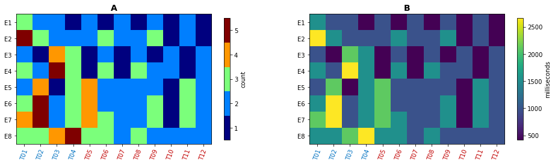

```python
plt.figure(figsize=(16,5))
stringdata = get_examplestringdata('wilsonetal_ejn_2015')
plt.subplot(1,2,1)
m = longestsharedsubstringlength(stringdata, comparison=('Test','Exposure'))
plot_comparison(m, title='A', colorbarshrink=0.75, colorbarlabel='count')
ax = plt.gca()
t = ax.set_title('A', fontdict={'fontweight': 'bold', 'fontsize': 14})
plt.subplot(1,2,2)
m = longestsharedsubstringduration(stringdata, comparison=('Test','Exposure'))
plot_comparison(m, title='B', colorbarshrink=0.75, colorbarlabel='milliseconds')
ax = plt.gca()
t = ax.set_title('B', fontdict={'fontweight': 'bold', 'fontsize': 14})
```

Up to Supplementary Info Contents

## Supplementary Analysis 4

The string sets originate from: Wilson B, Kikuchi Y, Sun L, Hunter D, Dick F, Smith K, Thiele A, Griffiths TD, Marslen-Wilson WD, Petkov CI (2015) Auditory sequence processing reveals evolutionarily conserved regions of frontal cortex in macaques and humans. Nat Commun 6:8901. [link](http://www.nature.com/ncomms/2015/151117/ncomms9901/full/ncomms9901.html)

The authors "... use functional magnetic resonance imaging in Rhesus macaques and humans to examine the brain regions involved in processing the ordering relationships between auditory nonsense words in rule-based sequences." In their Supplementary Notes [link](http://www.nature.com/ncomms/2015/151117/ncomms9901/extref/ncomms9901-s1.pdf) they state: "In our case, the form of statistical learning that the behavioural results in both species support is the implicit learning of the relationships between elements in a sequence as a function of the probabilities with which they occur in the exposure corpus [2,3]. This type of process, has been argued to represent a critical initial step in sentence processing in the human brain [4]. Furthermore, this form of sequence processing has been suggested as a potential language precursor process and could be studied in extant nonhuman primates [5]."

In the experiment, the authors first exposed macaques and humans with strings conforming to grammatical rules, and then presented them with test strings that are either consistent with these rules or that contain illegal violations. The ultimate goals is to identify brain regions that are involved in processing rule-based sequences.

The behavioral results are presented in their Figure 1b [link](http://www.nature.com/ncomms/2015/151117/ncomms9901/full/ncomms9901.html#f1), but note that their Supplementary info [link](http://www.nature.com/ncomms/2015/151117/ncomms9901/extref/ncomms9901-s1.pdf) contains more detailed figures with the results per string.

The analysis here (Table S5 and Figure S3) shows that there is a bias in the length of the substrings shared between test and exposure strings, which provides a non-grammatical alternative explanation for the results.

The strings used in this study, and the grammatical rules that generated them, are also provided in their paper [link](http://www.nature.com/ncomms/2015/151117/ncomms9901/fig_tab/ncomms9901_F1.html). The elements that were used to build the strings ({a,c,d,g,f}) stand for short nonsense words (a: "klor", c: "biff", d: "jux", f: "cav", g: "dupp"). String labeling here is ours:

Exposure strings (rows):

- E

Test strings (columns):

- CT: consistent test strings
- VT: violating test string

## Table S5

**Longest substrings that are shared between exposure and test strings in Wilson et al. 2015a**. The substring lengths, and corresponding durations, are shown in Figure S3 below.

```python
stringdata = get_examplestringdata('wilsonetal_natcomm_2015')
HTML(longestsharedsubstringstable(stringdata, comparison=('Test','Exposure'), minlen=2,title=''))
```

|  | CT1 acgfc | CT2 adcfcg | CT3 acfcg | CT4 adcgfc | VT1 afgcd | VT2 afcdgc | VT3 fadgc | VT4 dcafgc |
| --- | --- | --- | --- | --- | --- | --- | --- | --- |
| E1 acf | acf acgfc | acf adcfcg | acf acfcg |  |  |  |  |  |
| E2 acfc | acfc acgfc acfc acgfc | acfc adcfcg | acfc acfcg | acfc adcgfc |  | acfc afcdgc |  |  |
| E3 acgf | acgf acgfc | acgf adcfcg | acgf acfcg acgf acfcg | acgf adcgfc |  |  |  |  |
| E4 acgfc | acgfc acgfc | acgfc adcfcg acgfc adcfcg | acgfc acfcg acgfc acfcg acgfc acfcg | acgfc adcgfc |  | acgfc afcdgc |  |  |
| E5 adcf |  | adcf adcfcg | adcf acfcg | adcf adcgfc |  |  | adcf fadgc | adcf dcafgc |
| E6 adcfc | adcfc acgfc | adcfc adcfcg | adcfc acfcg | adcfc adcgfc |  | adcfc afcdgc | adcfc fadgc | adcfc dcafgc |
| E7 adcfcg | adcfcg acgfc adcfcg acgfc | adcfcg adcfcg | adcfcg acfcg | adcfcg adcgfc |  | adcfcg afcdgc | adcfcg fadgc | adcfcg dcafgc |
| E8 adcgf | adcgf acgfc | adcgf adcfcg | adcgf acfcg | adcgf adcgfc |  |  | adcgf fadgc | adcgf dcafgc |
| E9 acgfcg | acgfcg acgfc | acgfcg adcfcg | acgfcg acfcg | acgfcg adcgfc |  | acgfcg afcdgc |  |  |

## Figure S3

**Image plots showing (A) the number of tokens and (B) corresponding duration of the longest substrings shared between habituation and test strings in Wilson et al. 2015a**. Grammar consistent strings (CT1-CT4) share longer substrings with habituation strings than grammar violation strings (VT1-VT4) do.

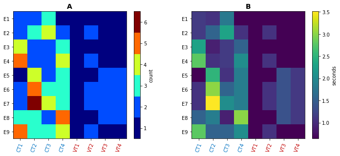

```python
plt.figure(figsize=(12,4.8))
stringdata = get_examplestringdata('wilsonetal_natcomm_2015')
plt.subplot(1,2,1)
m = longestsharedsubstringlength(stringdata, comparison=('Test','Exposure'))
plot_comparison(m, title='A', colorbarshrink=1, colorbarlabel='count')
ax = plt.gca()
t = ax.set_title('A', fontdict={'fontweight': 'bold', 'fontsize': 14})
plt.subplot(1,2,2)
m = longestsharedsubstringduration(stringdata, comparison=('Test','Exposure'))
plot_comparison(m, title='B', colorbarshrink=1, colorbarlabel='seconds')
ax = plt.gca()
t = ax.set_title('B', fontdict={'fontweight': 'bold', 'fontsize': 14})
```

Up to Supplementary Info Contents

## Supplementary Analysis 5

The string sets originate from: Chen J, ten Cate C (2015) Zebra finches can use positional and transitional cues to distinguish vocal element strings. *Behavioural Processes*, 117:29–34. [link](http://www.sciencedirect.com/science/article/pii/S0376635714001995)

In this paper the authors use Go-Nogo operant tests to examine whether zebra finches can use transitional cues to distinguish artificially constructed strings of natural song elements. From their abstract: "Zebra finches were trained with sequences differing in transitional and positional information and next tested with novel strings sharing positional and transitional similarities with the training strings. The results show that they can attend to both transitional and positional cues and that their sequential coding strategies can be biased toward transitional cues depending on the learning context."

## Their Experiment 1

The strings of Experiment 1 are given in their Table 1 [link](http://www.sciencedirect.com/science/article/pii/S0376635714001995/#tbl0005) (and printed in Table S5 below), and the results are provided in their Table 4 [link](http://www.sciencedirect.com/science/article/pii/S0376635714001995/#tbl0020). Birds were trained to distinguish the *Go* sound from the *NoGo* sound, and were then tested on probes *A1*, *A2*, *B1*, and *B2*. Differential responses to *A* and *B* sounds should distinguish between the use of element transitions and positions. See their Table 1 and text in section 2.3.1 for the rationale behind this design.

However, there is a bias in the length of the substrings shared between test and probe strings (see Tables S6 and Figure S4 below).

The behavioural results (Go: 0.87, NoGo:0.10, A1: 0.70, A2: 0.67, B1: 0.57, B2: 0.49; see their Table 4 [link](http://www.sciencedirect.com/science/article/pii/S0376635714001995/#tbl0020)) match this pattern very well and provides a non-grammatical alternative explanation for the results.

## Table S6

**Longest substrings (in orange) that are shared between training (*Go and NoGo*) and test (*A1, A2, B1, B2*) strings in Experiment 1 of Chen and ten Cate 2015**. The substring lengths, and corresponding durations, are shown in Figure S4 below.

```python
stringdata = get_examplestringdata('chentencate_behproc_2015')
HTML(longestsharedsubstringstable(stringdata, comparison=('Exp1_Test','Exp1_Training'), title=''))
```

|  | A1 abefcdabcdefab | A2 abefcdefabcdab | B1 abcedfceabdfab | B2 abcedfabdfceab |
| --- | --- | --- | --- | --- |
| Go abcdefabefcdab | abcdefabefcdab abefcdabcdefab abcdefabefcdab abefcdabcdefab | abcdefabefcdab abefcdefabcdab abcdefabefcdab abefcdefabcdab | abcdefabefcdab abcedfceabdfab abcdefabefcdab abcedfceabdfab | abcdefabefcdab abcedfabdfceab abcdefabefcdab abcedfabdfceab |
| NoGo abdfcedfabceab | abdfcedfabceab abefcdabcdefab abdfcedfabceab abefcdabcdefab | abdfcedfabceab abefcdefabcdab | abdfcedfabceab abcedfceabdfab abdfcedfabceab abcedfceabdfab abdfcedfabceab abcedfceabdfab abdfcedfabceab abcedfceabdfab abdfcedfabceab abcedfceabdfab abdfcedfabceab abcedfceabdfab | abdfcedfabceab abcedfabdfceab abdfcedfabceab abcedfabdfceab |

## Figure S4

**Image plots showing (A) the number of elements and (B) corresponding duration of the longest substrings shared between training and test strings in Experiment 1 of Chen and ten Cate 2015**. The duration of the shared substrings is estimated from the spectrograms in their paper [link](http://www.sciencedirect.com/science/article/pii/S0376635714001995/#fig0005).

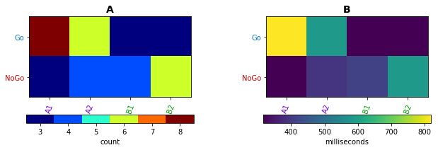

```python
import numpy as np
plt.figure(figsize=(11,3))
stringdata = get_examplestringdata('chentencate_behproc_2015')
plt.subplot(1,2,1)
m = longestsharedsubstringlength(stringdata, comparison=('Exp1_Test','Exp1_Training'))
plot_comparison(m, title='A', colorbarshrink=0.85, colorbarorientation='horizontal',  colorbarlabel='count')
ax = plt.gca()
t = ax.set_title('A', fontdict={'fontweight': 'bold', 'fontsize': 14})
plt.subplot(1,2,2)
m = longestsharedsubstringduration(stringdata, comparison=('Exp1_Test','Exp1_Training'))
plot_comparison(m, title='B', colorbarshrink=0.85, colorbarorientation='horizontal', colorbarlabel='milliseconds')
ax = plt.gca()
t = ax.set_title('B', fontdict={'fontweight': 'bold', 'fontsize': 14})
```

## Their Experiment 2, Test 1

Extended training sets are now used. The rationale of this test was " to examine whether the extended training set, in which transitional information remained identical for the stimuli of one set, but the positional information varied may have a positive effect on the use of transitional information." The strings of this experiment are given in their Table 3 [link](http://www.sciencedirect.com/science/article/pii/S0376635714001995/#tbl0015).

However, there is a bias in the length of the substrings shared between test and probe strings (see Tables S6 and Figure S5 below).

The behavioural results reported in the paper (see their Table 5 [link](http://www.sciencedirect.com/science/article/pii/S0376635714001995/#tbl0025)) match the pattern based on shared substring length quite well. All birds respond significantly more often *A3* than to *B3* sounds. This provides a non-grammatical alternative explanation for the results.

## Table S7

**Longest substrings (in orange) that are shared between training (*Go1, Go2, Go3, NoGo1, NoGo2, NoGo3*) and test (*A3, B3*) strings in Experiment 2, Test 1 of Chen and ten Cate 2015**. The substring lengths, and corresponding durations, are shown in Figure S5 below.

```python
stringdata = get_examplestringdata('chentencate_behproc_2015')
HTML(longestsharedsubstringstable(stringdata, comparison=('Exp2_Test1','Exp2_Training'), title=''))
```

|  | A3 cdefabcdabefab | B3 ceabdfabcedfab |
| --- | --- | --- |
| Go1 abcdefabefcdab | abcdefabefcdab cdefabcdabefab | abcdefabefcdab ceabdfabcedfab abcdefabefcdab ceabdfabcedfab abcdefabefcdab ceabdfabcedfab |
| Go2 abefcdabcdefab | abefcdabcdefab cdefabcdabefab | abefcdabcdefab ceabdfabcedfab abefcdabcdefab ceabdfabcedfab abefcdabcdefab ceabdfabcedfab |
| Go3 abefcdefabcdab | abefcdefabcdab cdefabcdabefab | abefcdefabcdab ceabdfabcedfab |
| NoGo1 abdfcedfabceab | abdfcedfabceab cdefabcdabefab | abdfcedfabceab ceabdfabcedfab abdfcedfabceab ceabdfabcedfab |
| NoGo2 abcedfceabdfab | abcedfceabdfab cdefabcdabefab abcedfceabdfab cdefabcdabefab abcedfceabdfab cdefabcdabefab | abcedfceabdfab ceabdfabcedfab |
| NoGo3 abcedfabdfceab | abcedfabdfceab cdefabcdabefab abcedfabdfceab cdefabcdabefab abcedfabdfceab cdefabcdabefab | abcedfabdfceab ceabdfabcedfab |

## Figure S5

**Image plots showing (A) the number of elements and (B) corresponding duration of longest substrings shared between training (*Go1, Go2, Go3, NoGo1, NoGo2, NoGo3*) and test (*A3, B3*) strings in Experiment 2, Test 1 of Chen and ten Cate 2015**.

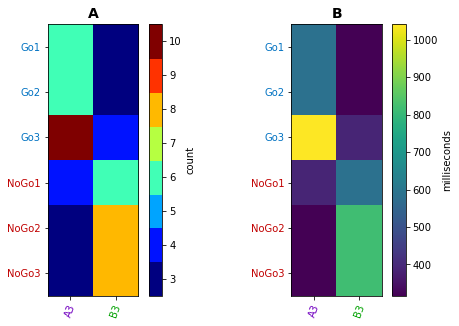

```python
plt.figure(figsize=(8,5))
stringdata = get_examplestringdata('chentencate_behproc_2015')
plt.subplot(1,2,1)
m = longestsharedsubstringlength(stringdata, comparison=('Exp2_Test1','Exp2_Training'))
plot_comparison(m, title='A', colorbarshrink=1,  colorbarlabel='count')
ax = plt.gca()
t = ax.set_title('A', fontdict={'fontweight': 'bold', 'fontsize': 14})
plt.subplot(1,2,2)
m = longestsharedsubstringduration(stringdata, comparison=('Exp2_Test1','Exp2_Training'))
plot_comparison(m, title='B', colorbarshrink=1, colorbarlabel='milliseconds')
ax = plt.gca()
t = ax.set_title('B', fontdict={'fontweight': 'bold', 'fontsize': 14})
```

## Their Experiment 2, Test 2

Test 2 essentially addressed the same question as Test 1, but provided more systematic variation in element position.

However, also here there is a bias in the length of the substrings shared between test and probe strings (see Tables S7 and Figure S6 below).

The behavioural results reported in the paper (see their Figure 2 [link](http://www.sciencedirect.com/science/article/pii/S0376635714001995/#fig0010)) match the pattern based on acoustic similarity measures above well. All birds respond significantly more often *A* than to *B* test sounds. This provides a non-grammatical alternative explanation for the results.

## Table S8

**Longest substrings (in orange) that are shared between training (*Go1, Go2, Go3, NoGo1, NoGo2, NoGo3*) and test (*A4, A5, A6, A7, A8, A9, B4, B5, B6, B7, B8, B9*) strings in Experiment 2, Test 2 of Chen and ten Cate 2015**. The substring lengths, and corresponding durations, are shown in Figure S6 below.

```python
stringdata = get_examplestringdata('chentencate_behproc_2015')
HTML(longestsharedsubstringstable(stringdata, comparison=('Exp2_Test2','Exp2_Training'), title=''))
```

|  | A4 cdefabefcdabab | A5 efabefcdababcd | A6 abefcdababcdef | A7 efcdababcdefab | A8 cdababcdefabef | A9 ababcdefabefcd | B4 dfcedfabceabab | B5 cedfabceababdf | B6 dfabceababdfce | B7 abceababdfcedf | B8 ceababdfcedfab | B9 ababdfcedfabce |
| --- | --- | --- | --- | --- | --- | --- | --- | --- | --- | --- | --- | --- |
| Go1 abcdefabefcdab | abcdefabefcdab cdefabefcdabab | abcdefabefcdab efabefcdababcd | abcdefabefcdab abefcdababcdef | abcdefabefcdab efcdababcdefab | abcdefabefcdab cdababcdefabef | abcdefabefcdab ababcdefabefcd | abcdefabefcdab dfcedfabceabab abcdefabefcdab dfcedfabceabab | abcdefabefcdab cedfabceababdf abcdefabefcdab cedfabceababdf | abcdefabefcdab dfabceababdfce abcdefabefcdab dfabceababdfce | abcdefabefcdab abceababdfcedf | abcdefabefcdab ceababdfcedfab | abcdefabefcdab ababdfcedfabce abcdefabefcdab ababdfcedfabce |
| Go2 abefcdabcdefab | abefcdabcdefab cdefabefcdabab | abefcdabcdefab efabefcdababcd | abefcdabcdefab abefcdababcdef | abefcdabcdefab efcdababcdefab | abefcdabcdefab cdababcdefabef | abefcdabcdefab ababcdefabefcd | abefcdabcdefab dfcedfabceabab abefcdabcdefab dfcedfabceabab | abefcdabcdefab cedfabceababdf abefcdabcdefab cedfabceababdf | abefcdabcdefab dfabceababdfce abefcdabcdefab dfabceababdfce | abefcdabcdefab abceababdfcedf | abefcdabcdefab ceababdfcedfab | abefcdabcdefab ababdfcedfabce abefcdabcdefab ababdfcedfabce |
| Go3 abefcdefabcdab | abefcdefabcdab cdefabefcdabab abefcdefabcdab cdefabefcdabab | abefcdefabcdab efabefcdababcd | abefcdefabcdab abefcdababcdef | abefcdefabcdab efcdababcdefab | abefcdefabcdab cdababcdefabef | abefcdefabcdab ababcdefabefcd abefcdefabcdab ababcdefabefcd | abefcdefabcdab dfcedfabceabab | abefcdefabcdab cedfabceababdf | abefcdefabcdab dfabceababdfce | abefcdefabcdab abceababdfcedf | abefcdefabcdab ceababdfcedfab | abefcdefabcdab ababdfcedfabce |
| NoGo1 abdfcedfabceab | abdfcedfabceab cdefabefcdabab | abdfcedfabceab efabefcdababcd abdfcedfabceab efabefcdababcd | abdfcedfabceab abefcdababcdef | abdfcedfabceab efcdababcdefab abdfcedfabceab efcdababcdefab | abdfcedfabceab cdababcdefabef abdfcedfabceab cdababcdefabef | abdfcedfabceab ababcdefabefcd abdfcedfabceab ababcdefabefcd | abdfcedfabceab dfcedfabceabab | abdfcedfabceab cedfabceababdf | abdfcedfabceab dfabceababdfce | abdfcedfabceab abceababdfcedf | abdfcedfabceab ceababdfcedfab | abdfcedfabceab ababdfcedfabce |
| NoGo2 abcedfceabdfab | abcedfceabdfab cdefabefcdabab | abcedfceabdfab efabefcdababcd abcedfceabdfab efabefcdababcd | abcedfceabdfab abefcdababcdef | abcedfceabdfab efcdababcdefab abcedfceabdfab efcdababcdefab | abcedfceabdfab cdababcdefabef abcedfceabdfab cdababcdefabef | abcedfceabdfab ababcdefabefcd abcedfceabdfab ababcdefabefcd | abcedfceabdfab dfcedfabceabab abcedfceabdfab dfcedfabceabab abcedfceabdfab dfcedfabceabab abcedfceabdfab dfcedfabceabab abcedfceabdfab dfcedfabceabab | abcedfceabdfab cedfabceababdf abcedfceabdfab cedfabceababdf abcedfceabdfab cedfabceababdf abcedfceabdfab cedfabceababdf abcedfceabdfab cedfabceababdf | abcedfceabdfab dfabceababdfce abcedfceabdfab dfabceababdfce abcedfceabdfab dfabceababdfce abcedfceabdfab dfabceababdfce abcedfceabdfab dfabceababdfce | abcedfceabdfab abceababdfcedf abcedfceabdfab abceababdfcedf abcedfceabdfab abceababdfcedf abcedfceabdfab abceababdfcedf abcedfceabdfab abceababdfcedf | abcedfceabdfab ceababdfcedfab abcedfceabdfab ceababdfcedfab abcedfceabdfab ceababdfcedfab abcedfceabdfab ceababdfcedfab abcedfceabdfab ceababdfcedfab | abcedfceabdfab ababdfcedfabce abcedfceabdfab ababdfcedfabce abcedfceabdfab ababdfcedfabce abcedfceabdfab ababdfcedfabce abcedfceabdfab ababdfcedfabce |
| NoGo3 abcedfabdfceab | abcedfabdfceab cdefabefcdabab | abcedfabdfceab efabefcdababcd abcedfabdfceab efabefcdababcd | abcedfabdfceab abefcdababcdef | abcedfabdfceab efcdababcdefab abcedfabdfceab efcdababcdefab | abcedfabdfceab cdababcdefabef abcedfabdfceab cdababcdefabef | abcedfabdfceab ababcdefabefcd abcedfabdfceab ababcdefabefcd | abcedfabdfceab dfcedfabceabab | abcedfabdfceab cedfabceababdf | abcedfabdfceab dfabceababdfce | abcedfabdfceab abceababdfcedf | abcedfabdfceab ceababdfcedfab abcedfabdfceab ceababdfcedfab | abcedfabdfceab ababdfcedfabce abcedfabdfceab ababdfcedfabce |

## Figure S6

**Image plots showing (A) the number of elements and (B) corresponding duration of the longest substrings shared between training (*Go1, Go2, Go3, NoGo1, NoGo2, NoGo3*) and test (*A4, A5, A6, A7, A8, A9, B4, B5, B6, B7, B8, B9*) strings in Experiment 2, Test 2 of Chen and ten Cate 2015**.

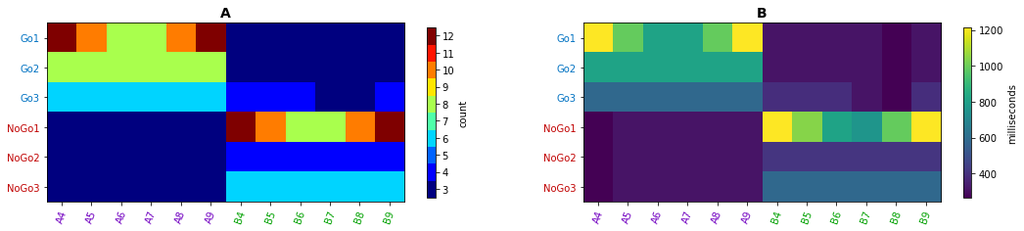

```python
plt.figure(figsize=(18,8))
stringdata = get_examplestringdata('chentencate_behproc_2015')
plt.subplot(1,2,1)
m = longestsharedsubstringlength(stringdata, comparison=('Exp2_Test2','Exp2_Training'))
plot_comparison(m, title='A', colorbarshrink=0.4,  colorbarlabel='count')
ax = plt.gca()
t = ax.set_title('A', fontdict={'fontweight': 'bold', 'fontsize': 14})
plt.subplot(1,2,2)
m = longestsharedsubstringduration(stringdata, comparison=('Exp2_Test2','Exp2_Training'))
plot_comparison(m, title='B', colorbarshrink=0.4, colorbarlabel='milliseconds')
ax = plt.gca()
t = ax.set_title('B', fontdict={'fontweight': 'bold', 'fontsize': 14})
```

## Their Experiment 2, Test 3

The rationale behind this test was: "If the birds used the transitional regularities to distinguish the sets, they might also be able to discriminate between shorter segments differing in transitional information. Stimuli of Test 3 consisted of four items only, but the segments kept the transitional regularities of either the Go or the Nogo training stimuli. They contained the most diagnostic bigrams for discriminating the stimuli by differences in element transitions."

According to the authors: "In this test, birds discriminated among the four-item segments according to their transitional regularities." See their Figure 3 [link](http://www.sciencedirect.com/science/article/pii/S0376635714001995/#fig0015).

However, here too there is a bias in the length of shared substrings that can alternatively explain the results (see Table S8 and Figure S7 below). *A* strings share longer substrings with the *Go* strings than *B* strings do. Conversely, *B* strings share longer substrings with *NoGo* strings than *A* strings do. Moreover, *A* test sounds are fully contained within *Go* sounds, but not within *NoGo* sounds. Conversely, *B* test sounds are fully contained within *NoGo* sounds, but not within *Go* sounds

## Table S9

**Longest substrings (in orange) that are shared between training (*Go1, Go2, Go3, NoGo1, NoGo2, NoGo3*) and test (*A10, A11, B10, B11*) strings in Experiment 2, Test 3 of Chen and ten Cate 2015**. The substring lengths, and corresponding durations, are shown in Figure S7 below.

```python
stringdata = get_examplestringdata('chentencate_behproc_2015')
HTML(longestsharedsubstringstable(stringdata, comparison=('Exp2_Test3','Exp2_Training'), minlen=2, title=''))
```

|  | A10 cdef | A11 efcd | B10 cedf | B11 dfce |
| --- | --- | --- | --- | --- |
| Go1 abcdefabefcdab | abcdefabefcdab cdef | abcdefabefcdab efcd |  | abcdefabefcdab dfce |
| Go2 abefcdabcdefab | abefcdabcdefab cdef | abefcdabcdefab efcd |  | abefcdabcdefab dfce |
| Go3 abefcdefabcdab | abefcdefabcdab cdef | abefcdefabcdab efcd |  | abefcdefabcdab dfce |
| NoGo1 abdfcedfabceab |  | abdfcedfabceab efcd | abdfcedfabceab cedf | abdfcedfabceab dfce |
| NoGo2 abcedfceabdfab |  | abcedfceabdfab efcd | abcedfceabdfab cedf | abcedfceabdfab dfce |
| NoGo3 abcedfabdfceab |  | abcedfabdfceab efcd | abcedfabdfceab cedf | abcedfabdfceab dfce |

## Figure S7

**Image plots showing (A) the number of elements and (B) corresponding duration of longest substrings shared between training (*Go1, Go2, Go3, NoGo1, NoGo2, NoGo3*) and test (*A10, A11, B10, B11*) strings in Experiment 2, Test 3 of Chen and ten Cate 2015**.

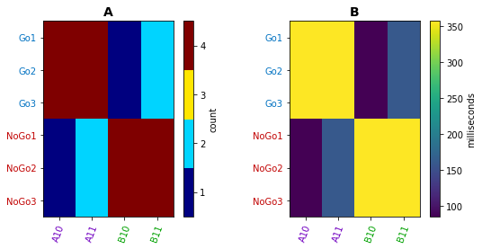

```python
plt.figure(figsize=(9,4))
stringdata = get_examplestringdata('chentencate_behproc_2015')
plt.subplot(1,2,1)
m = longestsharedsubstringlength(stringdata, comparison=('Exp2_Test3','Exp2_Training'))
plot_comparison(m, title='A', colorbarshrink=1.0,  colorbarlabel='count')
ax = plt.gca()
t = ax.set_title('A', fontdict={'fontweight': 'bold', 'fontsize': 14})
plt.subplot(1,2,2)
m = longestsharedsubstringduration(stringdata, comparison=('Exp2_Test3','Exp2_Training'))
plot_comparison(m, title='B', colorbarshrink=1.0, colorbarlabel='milliseconds')
ax = plt.gca()
t = ax.set_title('B', fontdict={'fontweight': 'bold', 'fontsize': 14})
```

Up to Supplementary Info Contents

## Figure S8

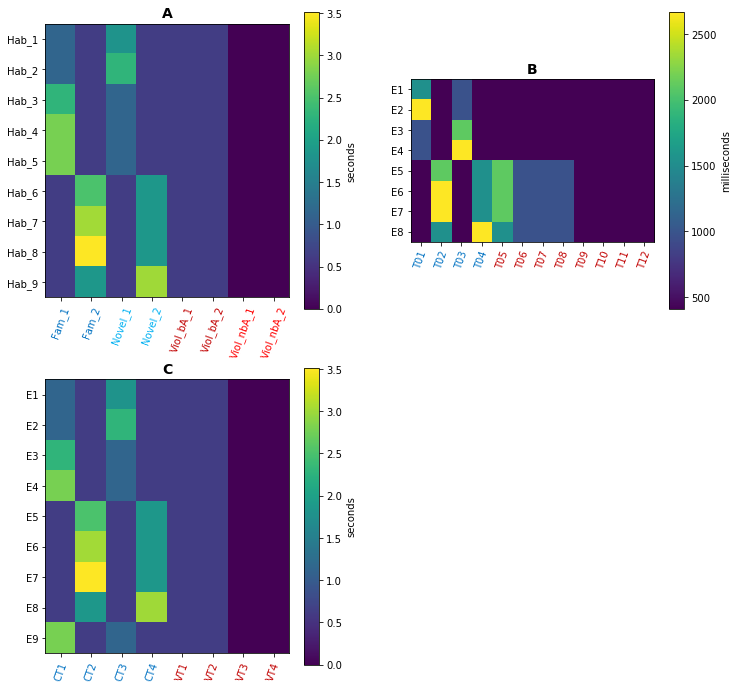

```python
plt.figure(figsize=(12,12))
plt.subplot(2,2,1)
stringdata = get_examplestringdata('wilsonetal_jneurosci_2013')
m = commonstartduration(stringdata, comparison=('Test', 'Hab'))
plot_comparison(m, title='',colorbarlabel='seconds')
ax = plt.gca()
t = ax.set_title('A', fontdict={'fontweight': 'bold', 'fontsize': 14})
plt.subplot(2,2,2)
stringdata = get_examplestringdata('wilsonetal_ejn_2015')
m = commonstartduration(stringdata, comparison=('Test', 'Exposure'))
plot_comparison(m, title='',colorbarlabel='milliseconds')
ax = plt.gca()
t = ax.set_title('B', fontdict={'fontweight': 'bold', 'fontsize': 14})
plt.subplot(2,2,3)
stringdata = get_examplestringdata('wilsonetal_natcomm_2015')
m = commonstartduration(stringdata, comparison=('Test', 'Exposure'))
plot_comparison(m, title='',colorbarlabel='seconds')
ax = plt.gca()
t = ax.set_title('C', fontdict={'fontweight': 'bold', 'fontsize': 14})
```

## Figure S9

**Image plots showing (A) the number of elements that are identical from the beginning of the string between habituation training sounds and test sounds, and (B) their average grouped by grammar type (PLS/NPLS) and grammaticality (GTS/UTS) in Experiment 3 of Saffran et al (2008).** Note that the difference in this type of similariy between grammatical (GTS) and ungrammatical strings (UTS) is almost twice as large in the case of the PLS as compared to NPLS. This is consistent with the results reported by the authors (see also Supplementary Analysis 1 ).

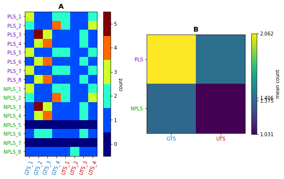

```python
plt.figure(figsize=(10,12))
plt.subplot(2,2,1)
stringdata = get_examplestringdata('saffranetal_cog_2008')
m = commonstartlength(stringdata, comparison=('Test', 'Fam'))
# m = samestart(stringdata, 3, comparison='Familiarization_vs_Test')
plot_comparison(m, title='', colorbarshrink=1, colorbarlabel='count')
ax = plt.gca()
t = ax.set_title('A', fontdict={'fontweight': 'bold', 'fontsize': 14})
plt.subplot(2,2,2)
PLS_GTS = np.array(m.get_matrix()).T[:8,:4]
NPLS_GTS = np.array(m.get_matrix()).T[8:,:4]
PLS_UTS = np.array(m.get_matrix()).T[:8,4:]
NPLS_UTS = np.array(m.get_matrix()).T[8:,4:]
meanar = np.array([[PLS_GTS.mean(), PLS_UTS.mean()], [NPLS_GTS.mean(), NPLS_UTS.mean()]])
plt.imshow(meanar, interpolation='nearest')
plt.colorbar(ticks=meanar.flatten(), shrink=0.70, label='mean count')
ax = plt.gca()
t = ax.set_title('B', fontdict={'fontweight': 'bold', 'fontsize': 14})
plt.xticks([0,1],['GTS', 'UTS'])
plt.yticks([0,1],['PLS', 'NPLS'])
l = ax.get_xticklabels()
l[0].set_color('#0071c1')
l[1].set_color('#c00000')
l = ax.get_yticklabels()
l[0].set_color('#7100c0')
l[1].set_color('#00a000')
```

Up to Supplementary Info Contents

## Supplementary Analysis 7

The string sets originate from the study of Abe K, Watanabe D (2011) Songbirds possess the spontaneous ability to discriminate syntactic rules. Nat Neurosci 14:1067–1074. [[link](http://www.nature.com/neuro/journal/v14/n8/full/nn.2869.html)].

Abe and Watanabe (2011) tested whether or not Bengalese finches spontaneously learn a context-free grammar from the examples they were presented with (NEF and EF stimuli, see strings below). They did this by measuring the birds' responses to test stimuli, some of which conform to the grammar (COR and CES stimuli), and some of which do not (AFP, AFC and RAND stimuli). The results provided in their Figure 3d show that grammar-conforming COR and CES stimuli are not treated differently from training stimuli, but grammar-violationg AFP, AFC, and RAND stimuli are.

A crosscorrelation between two strings is calculated by fully sliding one across the other in a stepwise fashion and counting at every step how many elements correspond between them. From the resulting counts, the maximum is taken. For example, the crosscorrelation between the strings *A1C1F1* and *A1C2F1* is: [0,0,2,0,0]. Its maximum is 2.

The strings were not published in Abe and Watanabe (2011), but they were graciously provided to us and we analysed them in Beckers et al (2012). For completeness, we also print them here:

```python
strings = get_examplestringdata('abewatanabe_natneurosci_2011')
print(strings)
```

```
All:
    NEF01   : A1C1F1
    NEF02   : A1C2F1
    NEF03   : A1C3F1
    NEF04   : A1C4F1
    NEF05   : A2C1F2
    NEF06   : A2C2F2
    NEF07   : A2C3F2
    NEF08   : A2C4F2
    NEF09   : A3C1F3
    NEF10   : A3C2F3
    NEF11   : A3C3F3
    NEF12   : A3C4F3
    NEF13   : A4C1F4
    NEF14   : A4C2F4
    NEF15   : A4C3F4
    NEF16   : A4C4F4
    EF01    : A1A2C2F2F1
    EF02    : A1A2C3F2F1
    EF03    : A1A2C4F2F1
    EF04    : A1A3C1F3F1
    EF05    : A1A3C3F3F1
    EF06    : A1A3C4F3F1
    EF07    : A1A4C1F4F1
    EF08    : A1A4C2F4F1
    EF09    : A1A4C4F4F1
    EF10    : A2A1C1F1F2
    EF11    : A2A1C2F1F2
    EF12    : A2A1C3F1F2
    EF13    : A2A3C2F3F2
    EF14    : A2A3C3F3F2
    EF15    : A2A3C4F3F2
    EF16    : A2A4C1F4F2
    EF17    : A2A4C3F4F2
    EF18    : A2A4C4F4F2
    EF19    : A3A1C1F1F3
    EF20    : A3A1C2F1F3
    EF21    : A3A1C3F1F3
    EF22    : A3A2C1F2F3
    EF23    : A3A2C2F2F3
```

[output cut: 110 more lines]

```
AFP: [AFP01, AFP02, AFP03, AFP04, AFP05, AFP06, AFP07, AFP08, AFP09, AFP10, AFP11, AFP12]

ACF: [ACF01, ACF02, ACF03, ACF04, ACF05, ACF06, ACF07, ACF08, ACF09, ACF10, ACF11, ACF12]

RAN: [RAN01, RAN02, RAN03, RAN04, RAN05, RAN06, RAN07, RAN08, RAN09, RAN10, RAN11, RAN12]

CES: [CES01, CES02, CES03, CES04, CES05, CES06, CES07, CES08, CES09, CES10, CES11, CES12]

AES: [AES01, AES02, AES03, AES04, AES05, AES06, AES07, AES08, AES09, AES10, AES11, AES12]

AES2: [AES2_01, AES2_02, AES2_03, AES2_04, AES2_05, AES2_06, AES2_07, AES2_08, AES2_09, AES2_10, AES2_11, AES2_12]

GrammaticalTest: [COR01, COR02, COR03, COR04, COR05, COR06, COR07, COR08, COR09, COR10, COR11, COR12, CES01, CES02, CES03, CES04, CES05, CES06, CES07, CES08, CES09, CES10, CES11, CES12]

UngrammaticalTest: [AFP01, AFP02, AFP03, AFP04, AFP05, AFP06, AFP07, AFP08, AFP09, AFP10, AFP11, AFP12, ACF01, ACF02, ACF03, ACF04, ACF05, ACF06, ACF07, ACF08, ACF09, ACF10, ACF11, ACF12, RAN01, RAN02, RAN03, RAN04, RAN05, RAN06, RAN07, RAN08, RAN09, RAN10, RAN11, RAN12, AES01, AES02, AES03, AES04, …
```

## Figure S10

**Maximum crosscorrelation values between (A) familiarization strings (*NEF* and *EF*, rows) and test strings (*COR*, *AFP*, *ACF*, *RAND*, *CES*) strings, and between (B) familiarization strings (*NEF* and *EF*, rows) and test strings (*COR*, *AES*, *AES2*, *CES*) strings, corresponding to the two test in Fig. 3 of Abe and Watanabe (2011).** The grammatical COR strings share 4 out of 5 elements at matching positions (e.g. *A1A2C2F2F1* vs *A1A2C1F2F1*) each with 3 different EF strings, and the grammatical CES strings share 5 out of 7 elements with an EF string (e.g. *A2A3C2F3F2* vs *A1A2A3C2F3F2F1*). None of the non-conforming test strings show this level of acoustic resemblance.

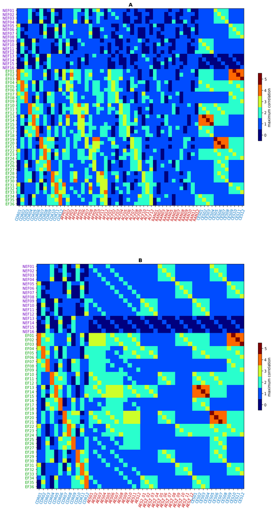

```python
strings = get_examplestringdata('abewatanabe_natneurosci_2011')

plt.figure(figsize=(14,25))

plt.subplot(2,1,1)
m = crosscorrelationmax(strings, comparison=('Fig3d_Test', 'Fam'))
plot_comparison(m, colorbarshrink=0.3, colorbarlabel='maximum correlation')
ax = plt.gca()
t = ax.set_title('A', fontdict={'fontweight': 'bold', 'fontsize': 14})

plt.subplot(2,1,2)
m = crosscorrelationmax(strings, comparison=('Fig3e_Test', 'Fam'))
plot_comparison(m, colorbarshrink=0.3, colorbarlabel='maximum correlation')
ax = plt.gca()
t = ax.set_title('B', fontdict={'fontweight': 'bold', 'fontsize': 14})
```

```python
#s = crosscorrelationmax(strings, comparison='Fig3d').get_pandaseries()
#s.max(level=['subgroups_Test', 'subgroups_Fam', 'strings_Test']).mean(level=['subgroups_Test', 'subgroups_Fam']).plot(kind='bar')
```

Up to Supplementary Info Contents

## Supplementary Analysis 8

The strings sets originate from: Chen J, Rossum D van, Cate C ten (2015) Artificial grammar learning in zebra finches and human adults: XYX versus XXY. Anim Cogn 18:151–164. [link](http://link.springer.com/article/10.1007/s10071-014-0786-4/fulltext.html)

In a series of tests, the authors present zebra finches with training and test strings with XYX and XXY structures, in which X and Y were zebra finch song elements (see their Figure 1 [link](http://link.springer.com/article/10.1007/s10071-014-0786-4/fulltext.html#Fig1)). Zebra finches discriminated the training stimuli, and some birds discriminated novel test stimuli when these were composed of familiar element types. None of the birds generalized the discrimination to novel element types. The authors conclude that zebra finches show evidence of simple rule abstraction related to positional learning, but found no evidence for a more abstract rule generalization.

However, there is a bias in acoustic similarity between training and test strings, based on the level of maximum crosscorrelation, that can explain or may have contributed to the results, without the use of rule abstraction.

The analyses relevant to the discussion here are those of their Experiment 1b, because the results of this experiment appear the provide the basis for the authors' claim of rule abstraction. Experiment 1a is addressed below for completeness, and to show that our alternative explanation is consistent with those results as well.

In Experiment 1b, the birds are trained to discriminate 6 XYX Go-stimuli from 6 XXY NoGo-stimuli, and then tested in two tests with XYX, XXY and XYY probes (their Table 2, [link](http://link.springer.com/article/10.1007/s10071-014-0786-4/fulltext.html#Tab2)). We label them as follows:

Training stimuli:

- Train_XYX_1 : ABA
- Train_XYX_2 : ADA
- Train_XYX_3 : BCB
- Train_XYX_4 : CAC
- Train_XYX_5 : CDC
- Train_XYX_6 : DAD
- Train_XXY_1 : AAB
- Train_XXY_2 : AAD
- Train_XXY_3 : BBC
- Train_XXY_4 : CCA
- Train_XXY_5 : CCD
- Train_XXY_6 : DDA

Test stimuli:

- Test1_XYX_1 : EFE
- Test1_XYX_2 : FEF
- Test1_XXY_1 : EEF
- Test1_XXY_2 : FFE
- Test1_XYY_1 : FEE
- Test1_XYY_2 : EFF
- Test2_XYX_1 : BAB
- Test2_XYX_2 : CBC
- Test2_XYX_3 : ACA
- Test2_XYX_4 : DCD
- Test2_XXY_1 : BBA
- Test2_XXY_2 : CCB
- Test2_XXY_3 : AAC
- Test2_XXY_4 : DDC

From the results (their Figure 5, [link](http://link.springer.com/article/10.1007/s10071-014-0786-4/fulltext.html#Fig5)), in which XYX test strings are treated like XYX training strings, but XXY test strings are not, the authors concluded that the birds may have learned the abstract XYX structure when familiar elements in test strings were used, but noted that it may also be that the birds learned to attend to a 'repetition rule': "if it starts with AA, BB, CC or DD, treat the stimulus as a No-Go stimulus; if these specific bigrams are not present, treat stimuli as a Go stimulus."

However, here too biases in the amount of crosscorrelation between training and test sounds can alternatively explain the observed results without sequence rules.

## Figure S11

**Maximum crosscorrelation values between Training strings (rows, *XYX* Go stimuli in blue, *XXY* NoGo stimuli in red) and test strings (columns, stimuli based on acoustically novel elements in black, XYX stimuli based on familiar elements in purple, XXY stimuli based on familiar elements in green) in Experiment 1b of Chen et al. (2015).** The *XYX* test sounds overall resemble the *XYX* Go training sounds more in this measure that the *XXY* test sounds do, while the *XXY* test sounds resemble the *XXY* NoGo stimuli more than the *XYX* test sounds do. This mirrors the reported results (see their Figure 5, [link](http://link.springer.com/article/10.1007/s10071-014-0786-4/fulltext.html#Fig5)).

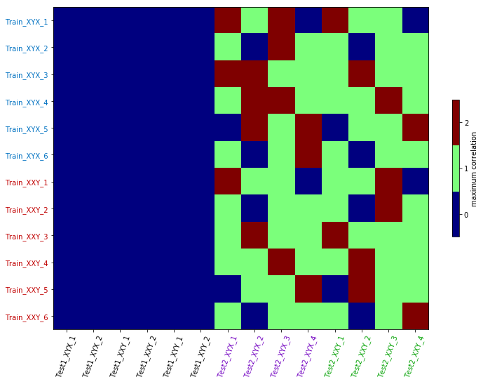

```python
strings = get_examplestringdata('chenetal_animcogn_2015')
m = crosscorrelationmax(strings, comparison=('Experiment_1b_Test', 'Experiment_1b_Train'))
plt.figure(figsize=(12,12))
plot_comparison(m, colorbarshrink=0.3, title='', colorbarlabel='maximum correlation')
```

## Figure S12

**Maximum crosscorrelation values between Training strings (rows) and test strings (columns) in (A) Phase 1, (B) Phase 2, (C) Phase 3, and (D) Phase 4 of Experiment 1a in Chen et al. (2015).** This mirrors the reported results well (see their Figure 2 [link](http://link.springer.com/article/10.1007/s10071-014-0786-4/fulltext.html#Fig2) and Figure 3 [link](http://link.springer.com/article/10.1007/s10071-014-0786-4/fulltext.html#Fig3)): the test stimuli that are consistently more similar in response level to the Go stimuli are always the ones that are not balanced in acoustic similarity, i.e. *BBA* in Phase 1, *CCB* in Phase 2, *DDC* in Phase 3, and *AAD* and *CCD* in Phase 4.

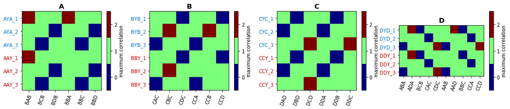

```python
plt.figure(figsize=(18,3))

plt.subplot(1,4,1)
m = crosscorrelationmax(strings, comparison=('Experiment_1a_phase_1_Test', 'Experiment_1a_phase_1_Train'))
plot_comparison(m, colorbarlabel='maximum correlation')
ax = plt.gca()
t = ax.set_title('A', fontdict={'fontweight': 'bold', 'fontsize': 14})

plt.subplot(1,4,2)
m = crosscorrelationmax(strings, comparison=('Experiment_1a_phase_2_Test', 'Experiment_1a_phase_2_Train'))
plot_comparison(m, colorbarlabel='maximum correlation')
ax = plt.gca()
t = ax.set_title('B', fontdict={'fontweight': 'bold', 'fontsize': 14})

plt.subplot(1,4,3)
m = crosscorrelationmax(strings, comparison=('Experiment_1a_phase_3_Test', 'Experiment_1a_phase_3_Train'))
plot_comparison(m, colorbarlabel='maximum correlation')
ax = plt.gca()
t = ax.set_title('C', fontdict={'fontweight': 'bold', 'fontsize': 14})

plt.subplot(1,4,4)
m = crosscorrelationmax(strings, comparison=('Experiment_1a_phase_4_Test', 'Experiment_1a_phase_4_Train'))
plot_comparison(m, colorbarlabel='maximum correlation')
ax = plt.gca()
t = ax.set_title('D', fontdict={'fontweight': 'bold', 'fontsize': 14})
```

Up to Supplementary Info Contents

## Supplementary Analysis 9

Crosscorrelation analyses of the strings in studies of Chen and ten Cate (2015; Experiment 2, all Tests) and of Wilson et al. (D) 2013 (E) 2015b, and (F) 2015a show a bias that can explain the behavioural results based on acoustic similarity. All of these studies have been analyzed above in the context of another bias (shared substring duration), and hence we provide here just the image plots that show the results.

## Figure S13

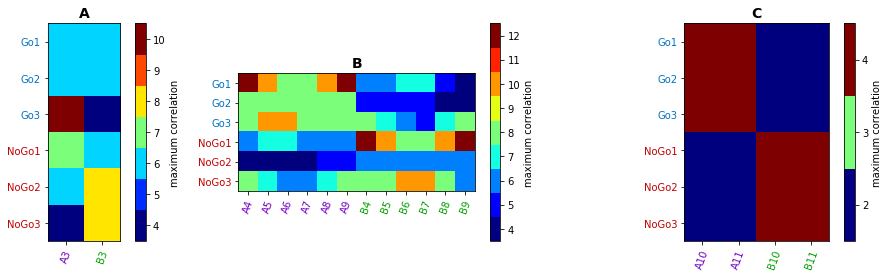

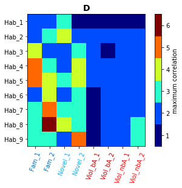

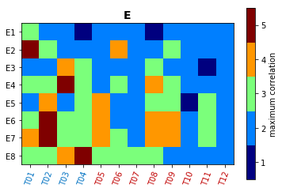

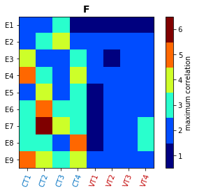

```python
stringdata = get_examplestringdata('chentencate_behproc_2015')
plt.figure(figsize=(18,4))
plt.subplot(1,3,1)
m = crosscorrelationmax(stringdata, comparison=('Exp2_Test1','Exp2_Training'))
plot_comparison(m, colorbarlabel='maximum correlation')
ax = plt.gca()
t = ax.set_title('A', fontdict={'fontweight': 'bold', 'fontsize': 14})

plt.subplot(1,3,2)
m = crosscorrelationmax(stringdata, comparison=('Exp2_Test2','Exp2_Training'))
plot_comparison(m, colorbarlabel='maximum correlation')
ax = plt.gca()
t = ax.set_title('B', fontdict={'fontweight': 'bold', 'fontsize': 14})

plt.subplot(1,3,3)
m = crosscorrelationmax(stringdata, comparison=('Exp2_Test3','Exp2_Training'))
plot_comparison(m, colorbarlabel='maximum correlation')
ax = plt.gca()
t = ax.set_title('C', fontdict={'fontweight': 'bold', 'fontsize': 14})

plt.figure()
stringdata = get_examplestringdata('wilsonetal_jneurosci_2013')
m = crosscorrelationmax(stringdata, comparison=('Test','Hab'))
plot_comparison(m, colorbarlabel='maximum correlation')
ax = plt.gca()
t = ax.set_title('D', fontdict={'fontweight': 'bold', 'fontsize': 14})

plt.figure()
stringdata = get_examplestringdata('wilsonetal_ejn_2015')
m = crosscorrelationmax(stringdata, comparison=('Test','Exposure'))
plot_comparison(m, colorbarlabel='maximum correlation')
ax = plt.gca()
t = ax.set_title('E', fontdict={'fontweight': 'bold', 'fontsize': 14})

plt.figure()
stringdata = get_examplestringdata('wilsonetal_natcomm_2015')
m = crosscorrelationmax(stringdata, comparison=('Test','Exposure'))
plot_comparison(m, colorbarlabel='maximum correlation')
ax = plt.gca()
t = ax.set_title('F', fontdict={'fontweight': 'bold', 'fontsize': 14})
```